# Error bars

Michael Hunt

30-03-2024

Measures of central tendency

When we have a set of data we often want to convey to others a summary description of it. What is a typical value, how widely spread are the data and is there any association between the values of this data set and those of another?

Measures of variation

What message do we want to convey?

Variance Standard deviation Standard error of the mean Confidence Interval Credible Interval

```
Rows: 179
Columns: 7
$ year      <dbl> 2016, 2016, 2016, 2016, 2016, 2016, 2016, 2016, 2016, 2016, 2016, 2016, 2016, 2016, 2016, 2016, 2016, 2016, 20…
$ month     <dbl> 8, 8, 8, 8, 8, 8, 8, 8, 8, 8, 8, 8, 8, 8, 8, 8, 8, 8, 8, 8, 8, 8, 8, 8, 8, 8, 8, 8, 8, 8, 8, 8, 8, 8, 8, 8, 8,…
$ date      <chr> "8/22/16", "8/22/16", "8/22/16", "8/22/16", "8/22/16", "8/22/16", "8/22/16", "8/22/16", "8/22/16", "8/22/16", …
$ site      <chr> "ivee", "ivee", "ivee", "ivee", "ivee", "ivee", "ivee", "ivee", "ivee", "ivee", "ivee", "ivee", "ivee", "ivee"…
$ transect  <dbl> 1, 1, 2, 3, 3, 3, 3, 3, 3, 3, 3, 3, 3, 3, 3, 3, 3, 3, 3, 3, 3, 3, 3, 4, 4, 4, 4, 4, 4, 4, 4, 4, 4, 4, 4, 4, 4,…
$ replicate <chr> "B", "B", "B", "B", "B", "B", "B", "B", "B", "B", "B", "B", "B", "B", "B", "B", "B", "B", "B", "B", "B", "B", …
$ size_mm   <dbl> 65, 70, 73, 42, 45, 55, 60, 62, 65, 65, 65, 66, 68, 68, 69, 70, 70, 70, 72, 72, 75, 85, 85, 65, 66, 71, 72, 73…
      year          month       date               site              transect      replicate            size_mm
 Min.   :2016   Min.   :8   Length:179         Length:179         Min.   :1.000   Length:179         Min.   : 40.0
 1st Qu.:2016   1st Qu.:8   Class :character   Class :character   1st Qu.:2.000   Class :character   1st Qu.: 60.0
 Median :2016   Median :8   Mode  :character   Mode  :character   Median :3.000   Mode  :character   Median : 70.0
 Mean   :2016   Mean   :8                                         Mean   :3.447                      Mean   : 68.9
 3rd Qu.:2016   3rd Qu.:8                                         3rd Qu.:5.000                      3rd Qu.: 78.0
 Max.   :2016   Max.   :8                                         Max.   :9.000                      Max.   :110.0
```

| replicate | n | mean_size_mm | sd_size_mm | se_size_mm | shapiro_wilk |
| --- | --- | --- | --- | --- | --- |
| B | 179 | 68.89777 | 13.66551 | 1.021408 | 0.09712248 |

[figure not shown]

### What are error bars for?

Error bars perform two main functions. One of these is a descriptive function, to give readers an idea of the spread of values within a data set, and this of the population from which the data have been drawn. The other is inferential, to enable readers to make inferences from a data set. For example to enable them to determine whether two data sets are plausibly drawn from the same population. THese two fucntions are quite different.

### Descriptive error bars

We could indicate the spread of values of a data set using the *range* or the *standard deviation*. Range error bars go from the highest to the lowest value in the data set, while standard deviation $SD$ is calculated using the formula

$$SD=\sqrt{\frac{\sum_{i=1}^n\left(y_i-\bar{y}\right)^2}{n-1}}$$
where the sum $\sum$ is of the squared differences between the sample values $y_i$ and the sample mean $\bar{y}$, over all $n$ data points in the sample. $SD$ can be thought of, roughly speaking, as the average deviation of data points in a sample from the mean of the sample.

For a sample of data points that are approximately normally distributed around their mean, about two thirds of the data set will lie within one standard deviation either side of the mean while about 95% of the data set will lie within about two standard deviations of the mean. Thus, only about 5% of all such data are more than two SDs away from the mean, so if a new data point *is* more than 2 SD from the mean, you can regard it as unusual.

The standard deviation of a sample will in general be approximately equal to the population standard deviation and so can be used as an estimate for it. It gives an idea of the spread of values within the population, and also of the likely spread of values in any other sample taken from that population. If we take sample after sample from the population we would get a different sample standard deviation every time. There would be no systematic reduction in standard deviation for larger sample sizes. Instead, these values would dot around the true value for the population, but with less and less fluctuation for larger sample sizes: the larger the sample size, the closer the sample standard deviation is likely to be to the population standard deviation.

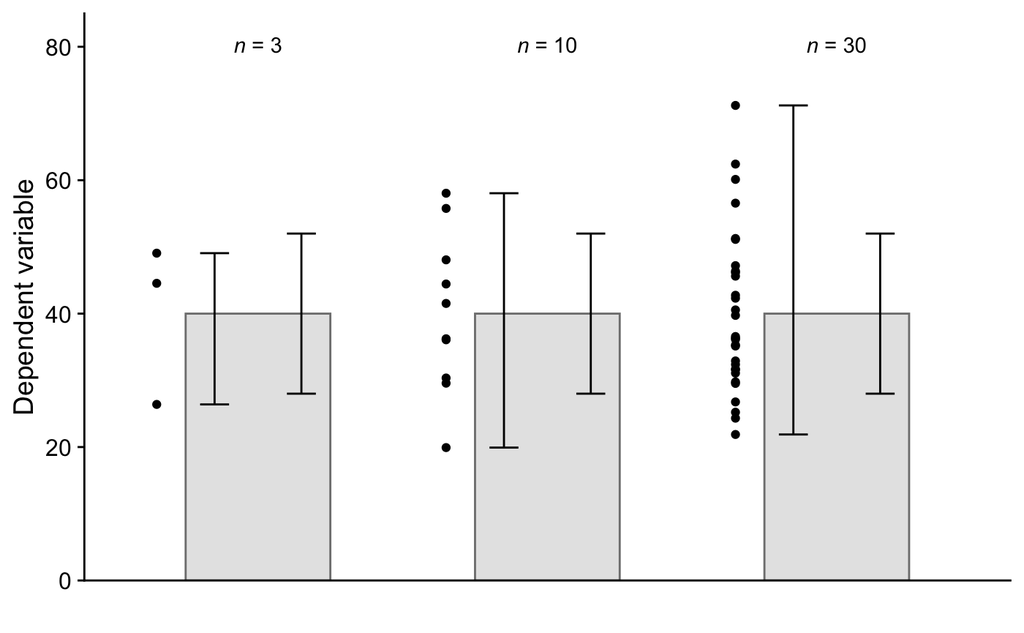